# Areal / lattice data.

## Areal / lattice data.

For typical lattice data, observed values are associated with areas, and the union of the areas observed cover the region of interest. The boundaries of the areas do not follow from the observed phenomen's properties, but typically from external constraints to the observation process.

Examples include:

- socio-economic data, related to administrative regions (census, administration)
- health data, related to hospital wards, or aggregated to adm. regions
- satellite imagery (aggregates, related to pixels)
- climate model predictions, as aggregates over regions

Problems include:

- estimate proportions or risks from count data:
  - assess whether there are (contiguous) *areas* with elevated risk
  - if this is the case, find correlations with other variables
- areal interpolation: interpolate (downscale/upscale) the observed values to some other units, that are hierchically related to the current areal units (e.g. landsat/modis, change of administrative regions, integration of health and census data)
- evaluating models (testing hypothesis) expressed as \(y = X\beta + e\), where either \(y\) and/or \(e\) exhibit autocorrelation

Typical analysis (see R package `spdep`) follows a path:

- build, and evaluate a spatial weight matrix (based on neighbours, or distance, or both)
- test for spatial correlation using Moran's I
- give significant spatial correlation, build models that account for that

The following is heavily inspired by Ch 17 and 18 of https://r-spatial.org/book .

```r
library(sf)
## Linking to GEOS 3.8.0, GDAL 3.0.2, PROJ 6.2.1
data(pol_pres15, package="spDataLarge")
head(pol_pres15[, c(1, 4, 6)])
## Simple feature collection with 6 features and 3 fields
## geometry type:  MULTIPOLYGON
## dimension:      XY
## bbox:           xmin: 235157.1 ymin: 366913.3 xmax: 281431.7 ymax: 413016.6
## epsg (SRID):    NA
## proj4string:    +proj=tmerc +lat_0=0 +lon_0=18.99999999999998 +k=0.9993 +x_0=500000 +y_0=-5300000 +ellps=GRS80 +towgs84=0,0,0 +units=m +no_defs
##    TERYT                name       types                       geometry
## 1 020101         BOLESŁAWIEC       Urban MULTIPOLYGON (((261089.5 38...
## 2 020102         BOLESŁAWIEC       Rural MULTIPOLYGON (((254150 3837...
## 3 020103            GROMADKA       Rural MULTIPOLYGON (((275346 3846...
## 4 020104        NOWOGRODZIEC Urban/rural MULTIPOLYGON (((251769.8 37...
## 5 020105          OSIECZNICA       Rural MULTIPOLYGON (((263423.9 40...
## 6 020106 WARTA BOLESŁAWIECKA       Rural MULTIPOLYGON (((267030.7 38...
library(spdep)
```

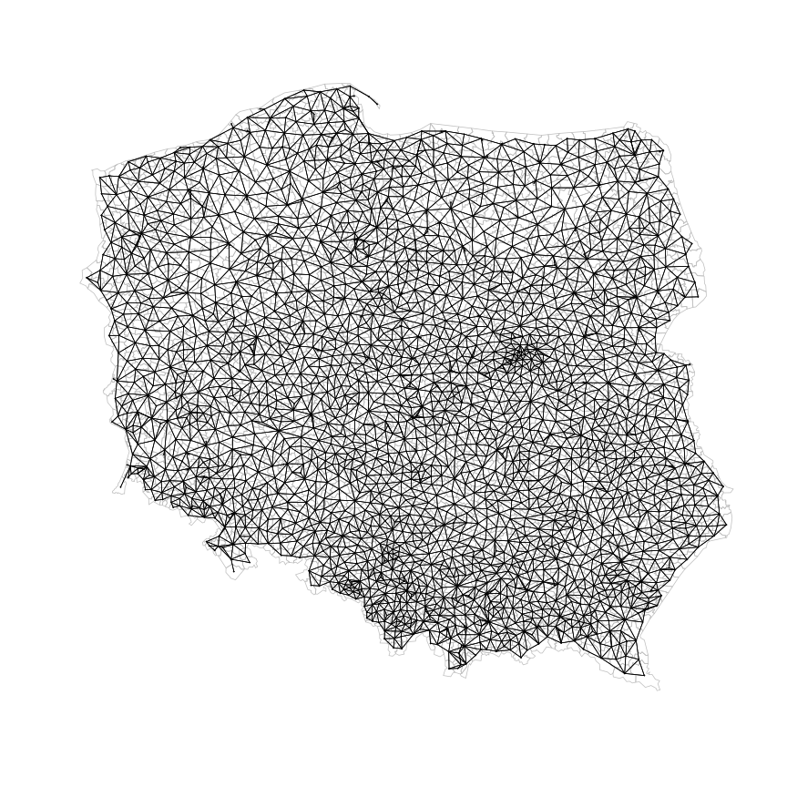

```r
p = poly2nb(pol_pres15)
plot(st_geometry(pol_pres15), border = 'grey')
plot(p, st_centroid(st_geometry(pol_pres15)), pch = 3, cex = .2, add = TRUE)
```

Finding queen neighbours using sf:

```r
st_queen <- function(a, b = a) st_relate(a, b, pattern = "F***T****")
as.nb.sgbp <- function(x, ...) {
  attrs <- attributes(x)
  x <- lapply(x, function(i) { if(length(i) == 0L) 0L else i } )
  attributes(x) <- attrs
  class(x) <- "nb"
  x
}
nb_sf_q <- as.nb.sgbp(st_queen(pol_pres15))
nb_q <- poly2nb(pol_pres15, queen=TRUE)
all.equal(nb_q, nb_q, check.attributes=FALSE)
```

```
## [1] TRUE
```

Moran's I: \[ I = \frac{n \sum_{(2)} w_{ij} z_i z_j}{S_0 \sum_{i=1}^{n} z_i^2} \] where \(x_i, i=1, \ldots, n\) are \(n\) observations on the numeric variable of interest, \(z_i = x_i - \bar{x}\), \(\bar{x} = \sum_{i=1}^{n} x_i / n\), \(\sum_{(2)} = \stackrel{\sum_{i=1}^{n} \sum_{j=1}^{n}}{i \neq j}\), \(w_{ij}\) are the spatial weights, and \(S_0 = \sum_{(2)} w_{ij}\).

First we test a random variable using the Moran test, here under the normality assumption (argument `randomisation=FALSE`, default `TRUE`):

```r
x <- rnorm(nrow(pol_pres15))
(mt <- moran.test(x, nb2listw(nb_q), randomisation=FALSE))
```

```
##
##  Moran I test under normality
##
## data:  x
## weights: nb2listw(nb_q)
##
## Moran I statistic standard deviate = -0.31691, p-value = 0.6243
## alternative hypothesis: greater
## sample estimates:
## Moran I statistic       Expectation          Variance
##     -0.0043270080     -0.0004009623      0.0001534707
```

The test variable is \(Z(I)=(I-E(I))/\sqrt{(Var(I))}\), which is standard normally distributed under the \(H_0\) of spatial independence.

Now try a real variable

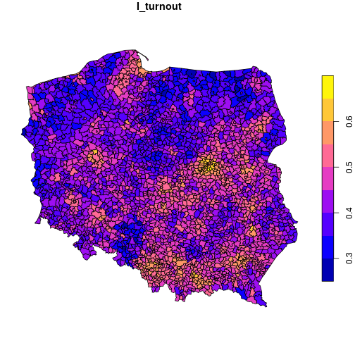

```r
plot(pol_pres15["I_turnout"])
```

```r
moran.test(pol_pres15$I_turnout, nb2listw(nb_q), randomisation=FALSE)
```

```
##
##  Moran I test under normality
##
## data:  pol_pres15$I_turnout
## weights: nb2listw(nb_q)
##
## Moran I statistic standard deviate = 55.481, p-value < 2.2e-16
## alternative hypothesis: greater
## sample estimates:
## Moran I statistic       Expectation          Variance
##      0.6869115119     -0.0004009623      0.0001534707
```

Alternatively, we could use a randomisation to compute \(Var(I)\):

```r
moran.test(pol_pres15$I_turnout, nb2listw(nb_q), randomisation=TRUE)
```

```
##
##  Moran I test under randomisation
##
## data:  pol_pres15$I_turnout
## weights: nb2listw(nb_q)
##
## Moran I statistic standard deviate = 55.479, p-value < 2.2e-16
## alternative hypothesis: greater
## sample estimates:
## Moran I statistic       Expectation          Variance
##      0.6869115119     -0.0004009623      0.0001534786
```

or use a permutation test:

```r
moran.mc(pol_pres15$I_turnout, nb2listw(nb_q), nsim = 999)
```

```
##
##  Monte-Carlo simulation of Moran I
##
## data:  pol_pres15$I_turnout
## weights: nb2listw(nb_q)
## number of simulations + 1: 1000
##
## statistic = 0.68691, observed rank = 1000, p-value = 0.001
## alternative hypothesis: greater
```

In case we are curious whether this could be a trend in northing and easting, we could try

```r
cc = st_coordinates(st_centroid(pol_pres15))
pol_pres15$x = cc[,1]
pol_pres15$y = cc[,2]
lm.morantest(lm(I_turnout~x+y, pol_pres15), nb2listw(nb_q))
```

```
##
##  Global Moran I for regression residuals
##
## data:
## model: lm(formula = I_turnout ~ x + y, data = pol_pres15)
## weights: nb2listw(nb_q)
##
## Moran I statistic standard deviate = 51.164, p-value < 2.2e-16
## alternative hypothesis: greater
## sample estimates:
## Observed Moran I      Expectation         Variance
##     0.6316916567    -0.0012018116     0.0001530128
```

```r
library(spatialreg)
(e1 = errorsarlm(I_turnout~x+y, pol_pres15, nb2listw(nb_q)))
```

```
##
## Call:
## errorsarlm(formula = I_turnout ~ x + y, data = pol_pres15, listw = nb2listw(nb_q))
## Type: error
##
## Coefficients:
##        lambda   (Intercept)             x             y
##  8.136417e-01  4.493338e-01  6.051636e-08 -6.195580e-08
##
## Log likelihood: 4450.706
```

```r
summary(e1)
```

```
##
## Call:
## errorsarlm(formula = I_turnout ~ x + y, data = pol_pres15, listw = nb2listw(nb_q))
##
## Residuals:
##        Min         1Q     Median         3Q        Max
## -0.1437602 -0.0254295 -0.0010257  0.0239821  0.1777382
##
## Type: error
## Coefficients: (asymptotic standard errors)
##                Estimate  Std. Error z value Pr(>|z|)
## (Intercept)  4.4933e-01  2.0061e-02 22.3982  < 2e-16
## x            6.0516e-08  2.5249e-08  2.3968  0.01654
## y           -6.1956e-08  2.6857e-08 -2.3069  0.02106
##
## Lambda: 0.81364, LR test value: 1914.3, p-value: < 2.22e-16
## Asymptotic standard error: 0.013834
##     z-value: 58.815, p-value: < 2.22e-16
## Wald statistic: 3459.2, p-value: < 2.22e-16
##
## Log likelihood: 4450.706 for error model
## ML residual variance (sigma squared): 0.0013991, (sigma: 0.037405)
## Number of observations: 2495
## Number of parameters estimated: 5
## AIC: -8891.4, (AIC for lm: -6979.1)
```

```r
(e2 = errorsarlm(I_turnout~types, pol_pres15, nb2listw(nb_q)))
```

```
##
## Call:
## errorsarlm(formula = I_turnout ~ types, data = pol_pres15, listw = nb2listw(nb_q))
## Type: error
##
## Coefficients:
##              lambda         (Intercept)          typesUrban
##          0.83827726          0.44072360          0.03664039
##    typesUrban/rural typesWarsaw Borough
##          0.01063703          0.05344443
##
## Log likelihood: 4592.881
```

```r
summary(e2)
```

```
##
## Call:
## errorsarlm(formula = I_turnout ~ types, data = pol_pres15, listw = nb2listw(nb_q))
##
## Residuals:
##         Min          1Q      Median          3Q         Max
## -0.13294913 -0.02326745 -0.00057984  0.02204095  0.14572490
##
## Type: error
## Coefficients: (asymptotic standard errors)
##                      Estimate Std. Error z value  Pr(>|z|)
## (Intercept)         0.4407236  0.0044307 99.4707 < 2.2e-16
## typesUrban          0.0366404  0.0021609 16.9564 < 2.2e-16
## typesUrban/rural    0.0106370  0.0016293  6.5284 6.646e-11
## typesWarsaw Borough 0.0534444  0.0171505  3.1162  0.001832
##
## Lambda: 0.83828, LR test value: 2214, p-value: < 2.22e-16
## Asymptotic standard error: 0.012727
##     z-value: 65.865, p-value: < 2.22e-16
## Wald statistic: 4338.2, p-value: < 2.22e-16
##
## Log likelihood: 4592.881 for error model
## ML residual variance (sigma squared): 0.0012299, (sigma: 0.035069)
## Number of observations: 2495
## Number of parameters estimated: 6
## AIC: -9173.8, (AIC for lm: -6961.8)
```

Models used:

- simultaneous autoregressive models (asdar 2nd ed, 9.4.1.1; spatial data science Ch 18)
- conditional autoregressive models (asdar 2nd ed, 9.4.1.2; spatial data science Ch 18)

Useful spdep vignettes:

- [creating neighbours](https://cran.r-project.org/web/packages/spdep/vignettes/nb.pdf)
- [Introduction to the North Carolina SIDS dataset](https://cran.r-project.org/web/packages/spdep/vignettes/sids.pdf)
- [Spatial weights objects as sparse matrices and graphs](https://cran.r-project.org/web/packages/spdep/vignettes/nb_igraph.html)
- [“The Problem of Spatial Autocorrelation:” forty years on](https://cran.r-project.org/web/packages/spdep/vignettes/CO69.pdf)

More modern approaches, using R-INLA:

- [Spatial Data Analysis with R-INLA with Some Extensions](https://www.jstatsoft.org/article/view/v063i20)

# Exercises

## Produc data

Load the produc dataset by

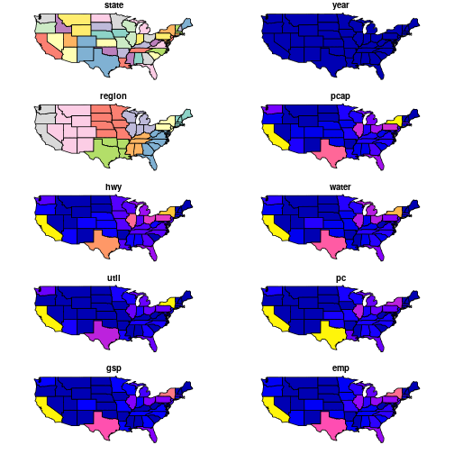

```r
# get US state delineations:
library(maps)
states.m = map('state', plot=FALSE, fill=TRUE)
IDs <- sapply(strsplit(states.m$names, ":"), function(x) x[1])
library(maptools)
## Checking rgeos availability: TRUE
states = map2SpatialPolygons(states.m, IDs=IDs)
# get the Produc dataset from plm:
library(plm)
data(Produc)
# convert into sf object:
library(sf)
Produc86 = subset(Produc, year == 1986)
st_geometry(Produc86) = st_as_sfc(states[-8])
plot(Produc86)
```

- What does variable `gsp` mean in this dataset?
- Is this variable spatially correlated?

```r
library(spdep)
nb = poly2nb(Produc86, queen = TRUE)
moran.test(Produc86$gsp, nb2listw(nb))
```

```
##
##  Moran I test under randomisation
##
## data:  Produc86$gsp
## weights: nb2listw(nb)
##
## Moran I statistic standard deviate = 0.28232, p-value = 0.3889
## alternative hypothesis: greater
## sample estimates:
## Moran I statistic       Expectation          Variance
##       0.003623260      -0.021276596       0.007778976
```

- How would you describe the temporal variability of `gsp` for the state `CALIFORNIA`, and is this variable temporally correlated?

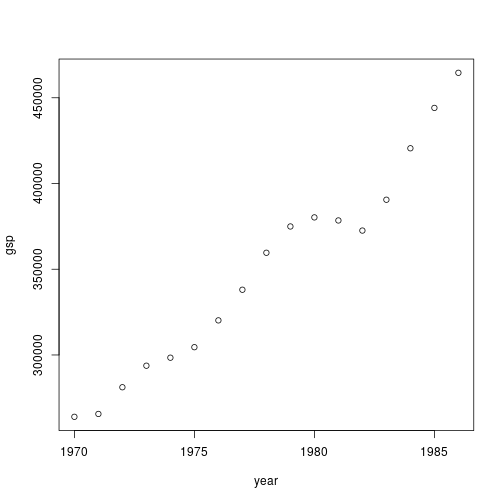

```r
Produc.ca = subset(Produc, state == "CALIFORNIA")
plot(gsp ~ year, Produc.ca)
```

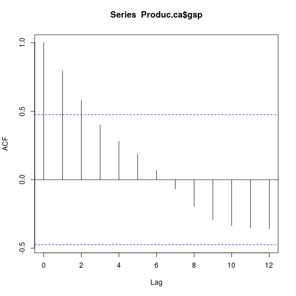

```r
acf(Produc.ca$gsp)
```

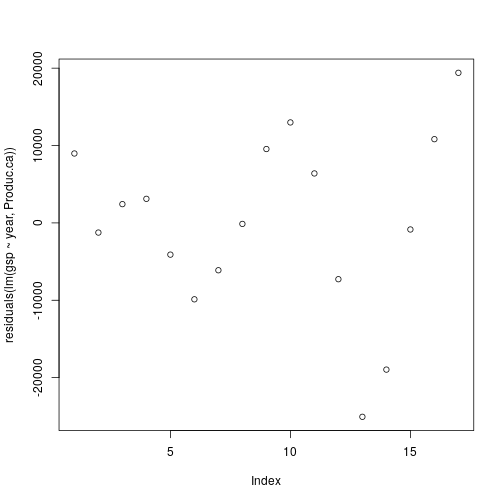

```r
plot(residuals(lm(gsp~year, Produc.ca)))
```

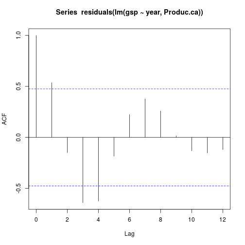

```r
acf(residuals(lm(gsp~year, Produc.ca)))
```

- compute a spatial error model for the year 1986, where you regress public capital stock on gross state product, and discuss the results.

```r
# do this on Monday
names(Produc86)
```

```
##  [1] "state"    "year"     "region"   "pcap"     "hwy"      "water"
##  [7] "util"     "pc"       "gsp"      "emp"      "unemp"    "geometry"
```

```r
e = errorsarlm(pcap~gsp, Produc86, nb2listw(nb))
summary(e)
```

```
##
## Call:
## errorsarlm(formula = pcap ~ gsp, data = Produc86, listw = nb2listw(nb))
##
## Residuals:
##       Min        1Q    Median        3Q       Max
## -15000.87  -2763.06   -495.88   1830.89  27329.75
##
## Type: error
## Coefficients: (asymptotic standard errors)
##               Estimate Std. Error z value  Pr(>|z|)
## (Intercept) 2.8662e+03 1.0040e+03  2.8546  0.004309
## gsp         3.2578e-01 1.0001e-02 32.5765 < 2.2e-16
##
## Lambda: -0.30974, LR test value: 1.9597, p-value: 0.16155
## Approximate (numerical Hessian) standard error: 0.2187
##     z-value: -1.4163, p-value: 0.1567
## Wald statistic: 2.0058, p-value: 0.1567
##
## Log likelihood: -486.4771 for error model
## ML residual variance (sigma squared): 36418000, (sigma: 6034.8)
## Number of observations: 48
## Number of parameters estimated: 4
## AIC: 980.95, (AIC for lm: 980.91)
```

```r
e_alt = lm(pcap~gsp, Produc86)
summary(e_alt)
```

```
##
## Call:
## lm(formula = pcap ~ gsp, data = Produc86)
##
## Residuals:
##      Min       1Q   Median       3Q      Max
## -14874.9  -2443.0   -555.9   2160.3  28778.5
##
## Coefficients:
##              Estimate Std. Error t value Pr(>|t|)
## (Intercept) 2.855e+03  1.220e+03    2.34   0.0237 *
## gsp         3.252e-01  1.065e-02   30.54   <2e-16 ***
## ---
## Signif. codes:  0 '***' 0.001 '**' 0.01 '*' 0.05 '.' 0.1 ' ' 1
##
## Residual standard error: 6359 on 46 degrees of freedom
## Multiple R-squared:  0.953,  Adjusted R-squared:  0.952
## F-statistic: 932.5 on 1 and 46 DF,  p-value: < 2.2e-16
```